# Speed Dating experiment - the difference in behavior and perception by gender and race, from an Asian Male's perspective

## by Kazu Fukuda

## Investigation Overview

I analyze Speed Dating experiment dataset on Kaggle(https://www.kaggle.com/annavictoria/speed-dating-experiment) to understand the difference in behavior and perception depending on participants' gender and race, especially from an Asian Male's perspective.

## Dataset Overview

In the experiment, each participant fills out their biological information(race and gender).  
In each session, participants rated partners based on the following criteria on a scale of 1-10:

##### [Rating]

**`like_o`** Overall, how much do you like this person?(1=don't like at all, 10=like a lot)  
**`attr_o`** Attractive rating of partner(1=awful, 10=great)  
**`sinc_o`** Sincere rating of partner(1=awful, 10=great)  
**`intel_o`** Intelligent rating of partner(1=awful, 10=great)  
**`fun_o`** Fun rating of partner(1=awful, 10=great)  
**`amb_o`** Ambitious rating of partner(1=awful, 10=great)  
**`shar_o`** Shared Interests/Hobbies rating of partner(1=awful, 10=great)

## The distribution of the probability of being selected by their partners and the overall rating score given to and received by their partners

1. The distribution of the probability of being selected is right-skew for both males and females, and there is no significant observed difference for both gender.
2. As for the mean rating given to their partners, it is interesting that the distribution of males is more widely spread(standard deviation:0.94) whereas the distribution of females is sharper(standard deviation:0.79).
3. The mean ratings received for males and females are distributed accordingly.

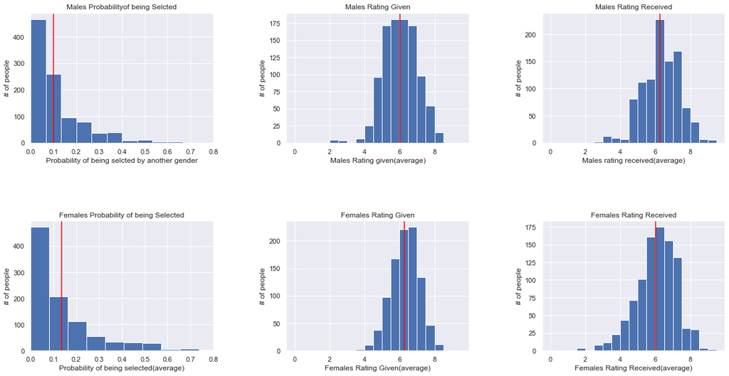

```python
# visualization
plt.figure(figsize = [20, 10])
plt.subplots_adjust(wspace=0.4, hspace=0.6)
bin_edges = np.arange(0, 10 , 0.5)

plt.subplot(2, 3, 1)
plt.hist(df_grouped_iid_male["dec_o_prob"])
plt.title("Males Probabilityof being Selcted", fontsize=12)
plt.ylabel("# of people")
plt.xlabel("Probability of being selcted by another gender")
plt.axvline(df_grouped_iid_male["dec_o_prob"].mean(), color='red')
plt.xlim(0, 0.8)

plt.subplot(2, 3, 2)
basic_hist(df_grouped_iid_male["like_o"],"Males Rating given", "Males Rating Given")

plt.subplot(2, 3, 3)
basic_hist(df_grouped_iid_male["like"],"Males rating received", "Males Rating Received")

plt.subplot(2, 3, 4)
plt.hist(df_grouped_iid_female["dec_o_prob"])
plt.title("Females Probability of being Selected", fontsize=12)
plt.ylabel("# of people")
plt.xlabel("Probability of being selected(average)")
plt.axvline(df_grouped_iid_female["dec_o_prob"].mean(), color='red')
plt.xlim(0, 0.8)

plt.subplot(2, 3, 5)
basic_hist(df_grouped_iid_female["like_o"],"Females Rating Given", "Females Rating Given")

plt.subplot(2, 3, 6)
basic_hist(df_grouped_iid_female["like"],"Females Rating Received", "Females Rating Received")
```

## The Asian and non Asian males' probability of being selected by females

1. The proportion of the first (lefthand-most) bin is the biggest.
2. The Asian Males' probability of being chosen by females(7%) is lower than that of non-Asian(10%)(P-value:0%)

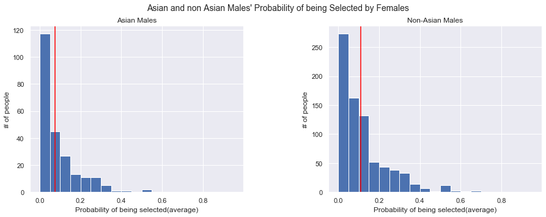

```python
# visualization for Asian and non Asian
bin_edges = np.arange(0, 1 , 0.05)

plt.figure(figsize = [15, 5])
plt.subplots_adjust(wspace=0.4, hspace=0.3)

plt.suptitle("Asian and non Asian Males' Probability of being Selected by Females", fontsize=14)

plt.subplot(1, 2, 1)
basic_hist(df_grouped_iid_male_asian["dec_o_prob"],"Probability of being selected", "Asian Males")

plt.subplot(1, 2, 2)
basic_hist(df_grouped_iid_male_non_asian["dec_o_prob"],"Probability of being selected", "Non-Asian Males")
```

## The Asian and non Asian males' mean rating score received by females

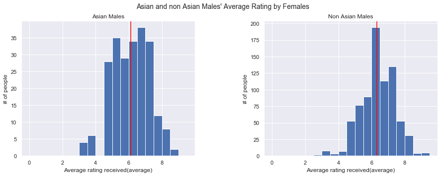

```python
# visualization for Asian and non Asian
bin_edges = np.arange(0,10, 0.5)

plt.figure(figsize = [15, 5])
plt.subplots_adjust(wspace=0.4, hspace=0.6)

plt.suptitle("Asian and non Asian Males' Average Rating by Females", fontsize=14)

plt.subplot(1, 2, 1)
basic_hist(df_grouped_iid_male_asian["like"],"Average rating received", "Asian Males")

plt.subplot(1, 2, 2)
basic_hist(df_grouped_iid_male_non_asian["like"],"Average rating received", "Non Asian Males")
```

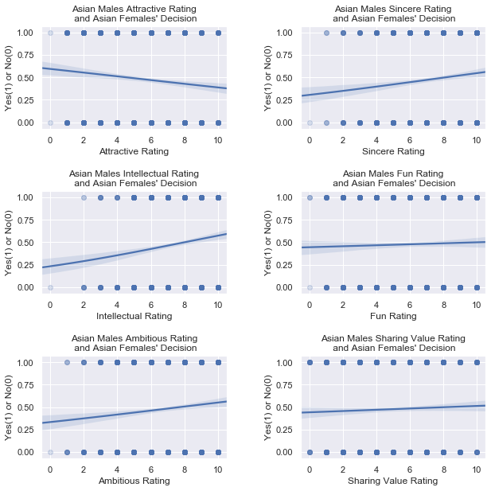

```python
# visualize the logistic regression of Asian Males attributes rating by Asian Females
plt.figure(figsize = [10, 10])
plt.subplots_adjust(wspace=0.4, hspace=0.6)

plt.subplot(3, 2, 1)
log_regplot(df_logit_asian, df_logit_asian['dec'], df_logit_asian['attr_o'],
            "Asian Females' Decision", "Attractive")

plt.subplot(3, 2, 2)
log_regplot(df_logit_asian, df_logit_asian['dec'], df_logit_asian['sinc_o'],
            "Asian Females' Decision", "Sincere")


plt.subplot(3, 2, 3)
log_regplot(df_logit_asian, df_logit_asian['dec'], df_logit_asian['intel_o'],
            "Asian Females' Decision", "Intellectual")

plt.subplot(3, 2, 4)
log_regplot(df_logit_asian, df_logit_asian['dec'], df_logit_asian['fun_o'],
            "Asian Females' Decision", "Fun")

plt.subplot(3, 2, 5)
log_regplot(df_logit_asian, df_logit_asian['dec'], df_logit_asian['amb_o'],
            "Asian Females' Decision", "Ambitious")

plt.subplot(3, 2, 6)
log_regplot(df_logit_asian, df_logit_asian['dec'], df_logit_asian['shar_o'],
            "Asian Females' Decision", "Sharing Value")
```

1. Sincere and intellectual have a higher coefficient than other attributes.
2. Attractive rating and the decision of the partner is negatively correlated

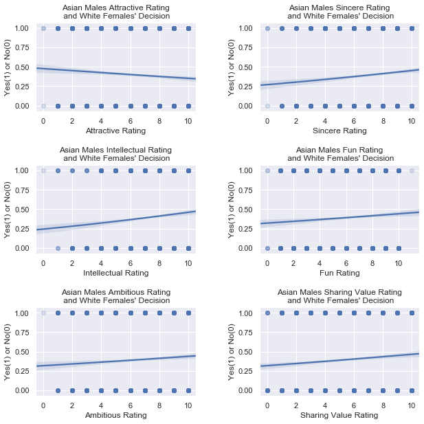

```python
# visualize the logistic regression of Asian Males attributes rating by White Females
plt.figure(figsize = [10, 10])
plt.subplots_adjust(wspace=0.4, hspace=0.6)

plt.subplot(3, 2, 1)
log_regplot(df_logit_white, df_logit_white['dec'], df_logit_white['attr_o'],
            "White Females' Decision", "Attractive")

plt.subplot(3, 2, 2)
log_regplot(df_logit_white, df_logit_white['dec'], df_logit_white['sinc_o'],
            "White Females' Decision", "Sincere")


plt.subplot(3, 2, 3)
log_regplot(df_logit_white, df_logit_white['dec'], df_logit_white['intel_o'],
            "White Females' Decision", "Intellectual")

plt.subplot(3, 2, 4)
log_regplot(df_logit_white, df_logit_white['dec'], df_logit_white['fun_o'],
            "White Females' Decision", "Fun")


plt.subplot(3, 2, 5)
log_regplot(df_logit_white, df_logit_white['dec'], df_logit_white['amb_o'],
            "White Females' Decision", "Ambitious")

plt.subplot(3, 2, 6)
log_regplot(df_logit_white, df_logit_white['dec'], df_logit_white['shar_o'],
            "White Females' Decision", "Sharing Value")
```